# TwoPuppies (study2children)

Adam Stone, PhD

04-18-2018

Let’s get all the puppy data and see histograms.

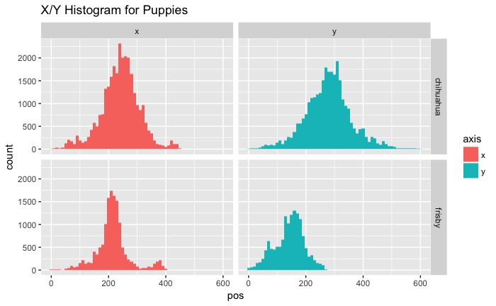

```r
# Libraries
library(tidyverse)
library(feather)
#library(stringr)
#library(cowplot)
# Import data
data <- read_feather("twopuppies.feather") %>%
  mutate(puppy = case_when(
    mark == 1 ~ "chihuahua",
    mark == 2 ~ "frisby"
  ))
# Get ages
# ages <- read_csv("childrenages.csv")
# data <- data %>% left_join(ages, by = "participant")
# data %>% select(participant,language,age) %>% distinct() # print data table
# Histogram of ages
data <- data %>% rename(x = xpos, y = ypos) %>%
  gather(axis, pos, x:y)
ggplot(data, aes(x = pos, fill = axis)) + geom_histogram(binwidth = 10) + ggtitle("X/Y Histogram for Puppies") + facet_grid(puppy ~ axis)
```

And let’s get mean and medians

```r
data_stats <- data %>%
  group_by(puppy, axis) %>%
  summarise(mean = mean(pos, na.rm=TRUE),
         median = median(pos, na.rm=TRUE))
data_stats
```

| puppy | axis | mean | median |
| --- | --- | --- | --- |
| chihuahua | x | 241.1481 | 244 |
| chihuahua | y | 279.4957 | 280 |
| frisby | x | 214.2752 | 213 |
| frisby | y | 142.5899 | 149 |

```r
globalmedian = data_stats$median
```

# Aubrey

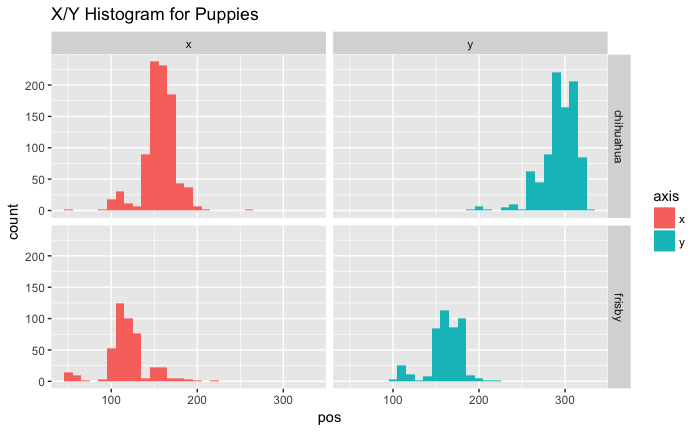

```r
aubrey <- read_csv("../Child Data/_twopuppies/Aubrey_Rec 02_TwoPuppiesData.csv") %>%
  mutate(puppy = case_when(
    mark == 1 ~ "chihuahua",
    mark == 2 ~ "frisby"
  )) %>%
  rename(x = xpos, y = ypos) %>%
  gather(axis, pos, x:y)
ggplot(aubrey, aes(x = pos, fill = axis)) + geom_histogram(binwidth = 10) + ggtitle("X/Y Histogram for Puppies") + facet_grid(puppy ~ axis)
```

```r
aubrey_stats <- aubrey %>%
  group_by(puppy, axis) %>%
  summarise(mean = mean(pos, na.rm=TRUE),
         median = median(pos, na.rm=TRUE)) %>%
  ungroup() %>%
  mutate(offset = median - globalmedian)
aubrey_stats
```

| puppy | axis | mean | median | offset |
| --- | --- | --- | --- | --- |
| chihuahua | x | 156.8231 | 158 | -86 |
| chihuahua | y | 293.9666 | 296 | 16 |
| frisby | x | 119.1451 | 119 | -94 |
| frisby | y | 161.7991 | 163 | 14 |

Aubrey’s offsets are approximately:

```r
aubrey_stats %>% group_by(axis) %>% summarise(offset = mean(offset))
```

| axis | offset |
| --- | --- |
| x | -90 |
| y | 15 |

# Owen

Owen’s data is misaligned. See below:

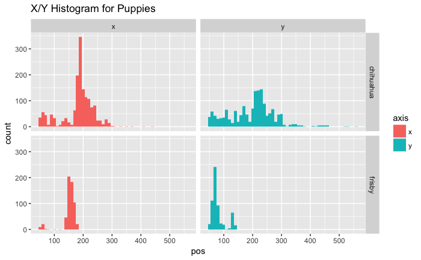

```r
owen <- read_csv("../Child Data/_twopuppies/Owen twin 4y2m POOR CALIB_TwoPuppiesData.csv") %>%
  mutate(puppy = case_when(
    mark == 1 ~ "chihuahua",
    mark == 2 ~ "frisby"
  )) %>%
  rename(x = xpos, y = ypos) %>%
  gather(axis, pos, x:y)
ggplot(owen, aes(x = pos, fill = axis)) + geom_histogram(binwidth = 10) + ggtitle("X/Y Histogram for Puppies") + facet_grid(puppy ~ axis)
```

```r
owen_stats <- owen %>%
  group_by(puppy, axis) %>%
  summarise(mean = mean(pos, na.rm=TRUE),
         median = median(pos, na.rm=TRUE)) %>%
  ungroup() %>%
  mutate(offset = median - globalmedian)
owen_stats
```

| puppy | axis | mean | median | offset |
| --- | --- | --- | --- | --- |
| chihuahua | x | 183.55483 | 191 | -53 |
| chihuahua | y | 197.78066 | 211 | -69 |
| frisby | x | 152.18212 | 156 | -57 |
| frisby | y | 80.13659 | 72 | -77 |

Owen’s offsets are approximately:

```r
owen_stats %>% group_by(axis) %>% summarise(offset = mean(offset))
```

| axis | offset |
| --- | --- |
| x | -55 |
| y | -73 |

# Lyla

I wanted to check Lyla’s data. Becaues when I was checking for AOI outliers, I noticed Lyla had a lot of high AOI %’s on the chest.

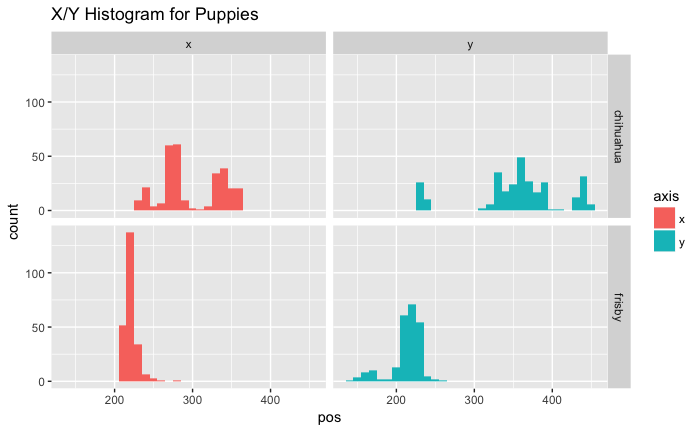

```r
lyla <- read_csv("../Child Data/_twopuppies/Rec 09 Lyla GREAT_TwoPuppiesData.csv") %>%
  mutate(puppy = case_when(
    mark == 1 ~ "chihuahua",
    mark == 2 ~ "frisby"
  )) %>%
  rename(x = xpos, y = ypos) %>%
  gather(axis, pos, x:y)
ggplot(lyla, aes(x = pos, fill = axis)) + geom_histogram(binwidth = 10) + ggtitle("X/Y Histogram for Puppies") + facet_grid(puppy ~ axis)
```

```r
lyla_stats <- lyla %>%
  group_by(puppy, axis) %>%
  summarise(mean = mean(pos, na.rm=TRUE),
         median = median(pos, na.rm=TRUE)) %>%
  ungroup() %>%
  mutate(offset = median - globalmedian)
lyla_stats
```

| puppy | axis | mean | median | offset |
| --- | --- | --- | --- | --- |
| chihuahua | x | 298.0206 | 281 | 37 |
| chihuahua | y | 356.3299 | 360 | 80 |
| frisby | x | 220.7692 | 219 | 6 |
| frisby | y | 213.4188 | 217 | 68 |

I don’t like her data for Chihuahua (seems scattered) so let’s only use Frisby to calculate offset

Lyla’s offsets are approximately:

```r
lyla_stats %>% filter(puppy=='frisby') %>% select(axis, offset)
```

| axis | offset |
| --- | --- |
| x | 6 |
| y | 68 |

# Mason

I wanted to check Mason’s data because I noticed he had a lot of high MidFaceCenter AOI percentages.

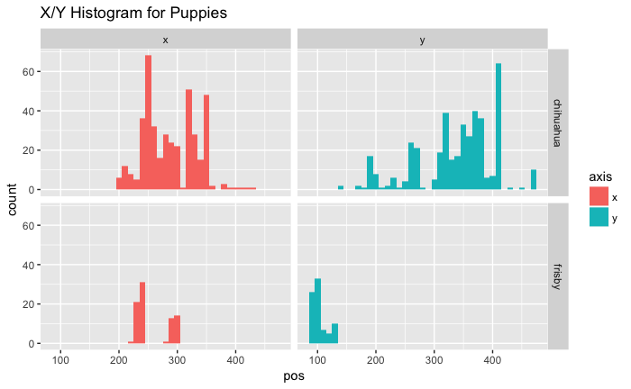

```r
mason <- read_csv("../Child Data/_twopuppies/Mason_CODA_6y_GOOD_TwoPuppiesData.csv") %>%
  mutate(puppy = case_when(
    mark == 1 ~ "chihuahua",
    mark == 2 ~ "frisby"
  )) %>%
  rename(x = xpos, y = ypos) %>%
  gather(axis, pos, x:y)
ggplot(mason, aes(x = pos, fill = axis)) + geom_histogram(binwidth = 10) + ggtitle("X/Y Histogram for Puppies") + facet_grid(puppy ~ axis)
```

```r
mason_stats <- mason %>%
  group_by(puppy, axis) %>%
  summarise(mean = mean(pos, na.rm=TRUE),
         median = median(pos, na.rm=TRUE)) %>%
  ungroup() %>%
  mutate(offset = median - globalmedian)
mason_stats
```

| puppy | axis | mean | median | offset |
| --- | --- | --- | --- | --- |
| chihuahua | x | 288.5049 | 280.5 | 36.5 |
| chihuahua | y | 337.8951 | 350.0 | 70.0 |
| frisby | x | 256.8025 | 240.0 | 27.0 |
| frisby | y | 102.8642 | 98.0 | -51.0 |

Mason’s offsets are approximately:

```r
mason_stats %>% group_by(axis) %>% summarise(offset = mean(offset))
```

| axis | offset |
| --- | --- |
| x | 31.75 |
| y | 9.50 |

# Ainsley

I wanted to check Ainsley’s data as an example of a GOOD kid…what kind of offsets would we see?

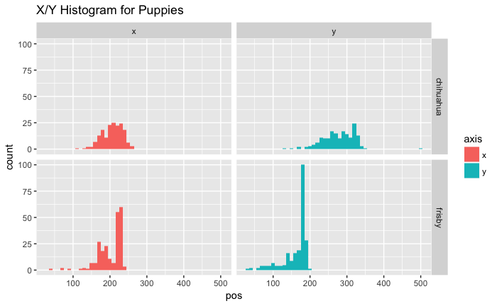

```r
ainsley <- read_csv("../Child Data/_twopuppies/Ainsely 5y1m GREAT_TwoPuppiesData.csv") %>%
  mutate(puppy = case_when(
    mark == 1 ~ "chihuahua",
    mark == 2 ~ "frisby"
  )) %>%
  rename(x = xpos, y = ypos) %>%
  gather(axis, pos, x:y)
ggplot(ainsley, aes(x = pos, fill = axis)) + geom_histogram(binwidth = 10) + ggtitle("X/Y Histogram for Puppies") + facet_grid(puppy ~ axis)
```

```r
ainsley_stats <- ainsley %>%
  group_by(puppy, axis) %>%
  summarise(mean = mean(pos, na.rm=TRUE),
         median = median(pos, na.rm=TRUE)) %>%
  ungroup() %>%
  mutate(offset = median - globalmedian)
ainsley_stats
```

| puppy | axis | mean | median | offset |
| --- | --- | --- | --- | --- |
| chihuahua | x | 206.3693 | 209.5 | -34.5 |
| chihuahua | y | 277.8125 | 282.0 | 2.0 |
| frisby | x | 201.5796 | 218.5 | 5.5 |
| frisby | y | 161.1460 | 177.0 | 28.0 |

Ainsley’s offsets are approximately:

```r
ainsley_stats %>% group_by(axis) %>% summarise(offset = mean(offset))
```

| axis | offset |
| --- | --- |
| x | -14.5 |
| y | 15.0 |

# CR03TA11

Checking CR03 - some high belly looking.

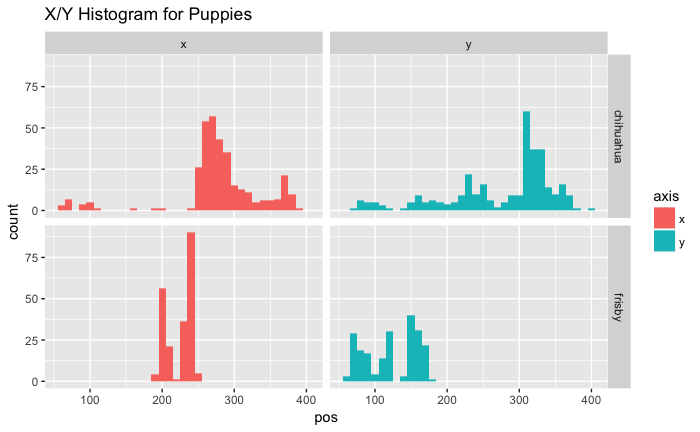

```r
cr03 <- read_csv("../Child Data/_twopuppies/CR03TA11_13m no calib obtained_TwoPuppiesData.csv") %>%
  mutate(puppy = case_when(
    mark == 1 ~ "chihuahua",
    mark == 2 ~ "frisby"
  )) %>%
  rename(x = xpos, y = ypos) %>%
  gather(axis, pos, x:y)
ggplot(cr03, aes(x = pos, fill = axis)) + geom_histogram(binwidth = 10) + ggtitle("X/Y Histogram for Puppies") + facet_grid(puppy ~ axis)
```

```r
cr03_stats <- cr03 %>%
  group_by(puppy, axis) %>%
  summarise(mean = mean(pos, na.rm=TRUE),
         median = median(pos, na.rm=TRUE)) %>%
  ungroup() %>%
  mutate(offset = median - globalmedian)
cr03_stats
```

| puppy | axis | mean | median | offset |
| --- | --- | --- | --- | --- |
| chihuahua | x | 278.7754 | 276 | 32 |
| chihuahua | y | 276.0479 | 309 | 29 |
| frisby | x | 224.4883 | 234 | 21 |
| frisby | y | 122.9202 | 122 | -27 |

CR03’s offsets are approximately:

```r
cr03_stats %>% group_by(axis) %>% summarise(offset = mean(offset))
```

| axis | offset |
| --- | --- |
| x | 26.5 |
| y | 1.0 |

Maybe a slight x axis offset to the right. But probably nothing to worry about.

# Desmond

Checking Desmond - some high LeftChestBottom looking

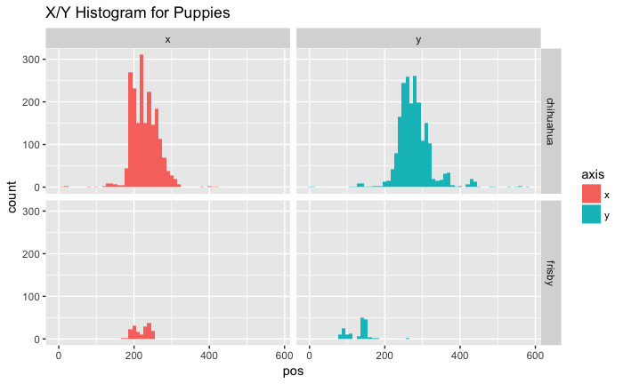

```r
desmond <- read_csv("../Child Data/_twopuppies/Desmond GOOD_TwoPuppiesData.csv") %>%
  mutate(puppy = case_when(
    mark == 1 ~ "chihuahua",
    mark == 2 ~ "frisby"
  )) %>%
  rename(x = xpos, y = ypos) %>%
  gather(axis, pos, x:y)
ggplot(desmond, aes(x = pos, fill = axis)) + geom_histogram(binwidth = 10) + ggtitle("X/Y Histogram for Puppies") + facet_grid(puppy ~ axis)
```

```r
desmond_stats <- desmond %>%
  group_by(puppy, axis) %>%
  summarise(mean = mean(pos, na.rm=TRUE),
         median = median(pos, na.rm=TRUE)) %>%
  ungroup() %>%
  mutate(offset = median - globalmedian)
desmond_stats
```

| puppy | axis | mean | median | offset |
| --- | --- | --- | --- | --- |
| chihuahua | x | 228.5113 | 225.0 | -19.0 |
| chihuahua | y | 278.4567 | 274.0 | -6.0 |
| frisby | x | 220.3882 | 225.5 | 12.5 |
| frisby | y | 128.6000 | 140.0 | -9.0 |

Desmond’s offsets are approximately:

```r
desmond_stats %>% group_by(axis) %>% summarise(offset = mean(offset))
```

| axis | offset |
| --- | --- |
| x | -3.25 |
| y | -7.50 |

Nothing to worry about.

# LA11BA11

Checking LA11BA11 - some high MidChestBottom looking

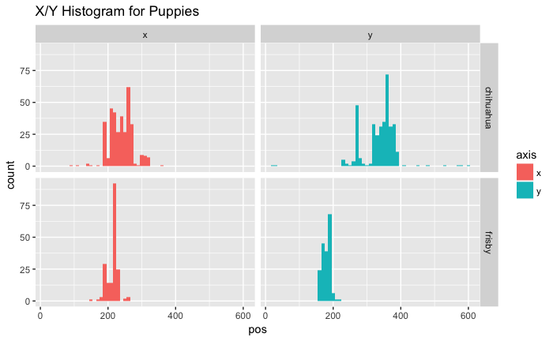

```r
la11 <- read_csv("../Child Data/_twopuppies/LA11BA11_5M_24D_GOOD_TwoPuppiesData.csv") %>%
  mutate(puppy = case_when(
    mark == 1 ~ "chihuahua",
    mark == 2 ~ "frisby"
  )) %>%
  rename(x = xpos, y = ypos) %>%
  gather(axis, pos, x:y)
ggplot(la11, aes(x = pos, fill = axis)) + geom_histogram(binwidth = 10) + ggtitle("X/Y Histogram for Puppies") + facet_grid(puppy ~ axis)
```

```r
la11_stats <- la11 %>%
  group_by(puppy, axis) %>%
  summarise(mean = mean(pos, na.rm=TRUE),
         median = median(pos, na.rm=TRUE)) %>%
  ungroup() %>%
  mutate(offset = median - globalmedian)
la11_stats
```

| puppy | axis | mean | median | offset |
| --- | --- | --- | --- | --- |
| chihuahua | x | 238.7714 | 239 | -5 |
| chihuahua | y | 338.3800 | 349 | 69 |
| frisby | x | 214.7174 | 220 | 7 |
| frisby | y | 179.5870 | 181 | 32 |

LA11’s offsets are approximately:

```r
la11_stats %>% group_by(axis) %>% summarise(offset = mean(offset))
```

| axis | offset |
| --- | --- |
| x | 1.0 |
| y | 50.5 |

Maybe y-axis should be looked at.

# MA01WA22

Checking MA01WA22 - several high MidFaceCenter and MidFaceTop looking

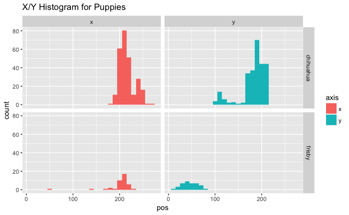

```r
ma01 <- read_csv("../Child Data/_twopuppies/ma01wa22 10m GOOD_TwoPuppiesData.csv") %>%
  mutate(puppy = case_when(
    mark == 1 ~ "chihuahua",
    mark == 2 ~ "frisby"
  )) %>%
  rename(x = xpos, y = ypos) %>%
  gather(axis, pos, x:y)
ggplot(ma01, aes(x = pos, fill = axis)) + geom_histogram(binwidth = 10) + ggtitle("X/Y Histogram for Puppies") + facet_grid(puppy ~ axis)
```

```r
ma01_stats <- ma01 %>%
  group_by(puppy, axis) %>%
  summarise(mean = mean(pos, na.rm=TRUE),
         median = median(pos, na.rm=TRUE)) %>%
  ungroup() %>%
  mutate(offset = median - globalmedian) %>%
  print()
```

| puppy | axis | mean | median | offset |
| --- | --- | --- | --- | --- |
| chihuahua | x | 216.4828 | 213.0 | -31.0 |
| chihuahua | y | 182.9847 | 189.0 | -91.0 |
| frisby | x | 201.4250 | 208.5 | -4.5 |
| frisby | y | 46.5250 | 45.5 | -103.5 |

MA01’s offsets are approximately:

```r
ma01_stats %>% group_by(axis) %>% summarise(offset = mean(offset))
```

| axis | offset |
| --- | --- |
| x | -17.75 |
| y | -97.25 |

Yeah look at the y-axis.

# NI12GO05

Lots of high midchestcenter and midchestbottom

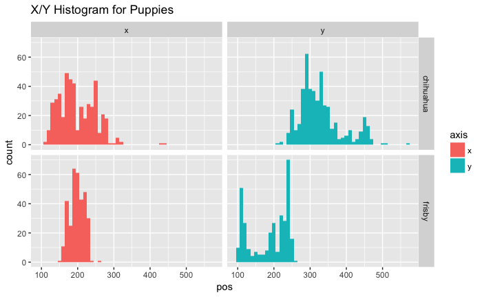

```r
ni12 <- read_csv("../Child Data/_twopuppies/NI12GO05_5M_4D_GOOD_TwoPuppiesData.csv") %>%
  mutate(puppy = case_when(
    mark == 1 ~ "chihuahua",
    mark == 2 ~ "frisby"
  )) %>%
  rename(x = xpos, y = ypos) %>%
  gather(axis, pos, x:y)
ggplot(ni12, aes(x = pos, fill = axis)) + geom_histogram(binwidth = 10) + ggtitle("X/Y Histogram for Puppies") + facet_grid(puppy ~ axis)
```

```r
ni12_stats <- ni12 %>%
  group_by(puppy, axis) %>%
  summarise(mean = mean(pos, na.rm=TRUE),
         median = median(pos, na.rm=TRUE)) %>%
  ungroup() %>%
  mutate(offset = median - globalmedian) %>%
  print()
```

| puppy | axis | mean | median | offset |
| --- | --- | --- | --- | --- |
| chihuahua | x | 199.0826 | 188 | -56 |
| chihuahua | y | 328.5826 | 317 | 37 |
| frisby | x | 198.9205 | 198 | -15 |
| frisby | y | 186.8838 | 201 | 52 |

NI12’s offsets are approximately:

```r
ni12_stats %>% group_by(axis) %>% summarise(offset = mean(offset))
```

| axis | offset |
| --- | --- |
| x | -35.5 |
| y | 44.5 |

Should at least fix the y-axis.

# Brooke

Seemed to not be good?

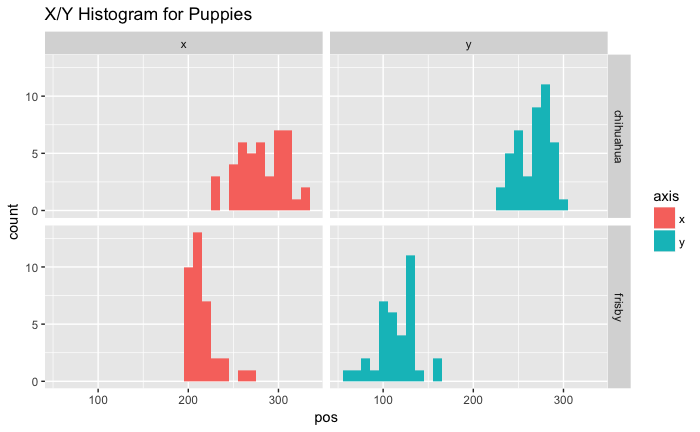

```r
brooke <- read_csv("../Child Data/_twopuppies/Rec 01 BAD CALIBRATION_TwoPuppiesData.csv") %>%
  mutate(puppy = case_when(
    mark == 1 ~ "chihuahua",
    mark == 2 ~ "frisby"
  )) %>%
  rename(x = xpos, y = ypos) %>%
  gather(axis, pos, x:y)
ggplot(brooke, aes(x = pos, fill = axis)) + geom_histogram(binwidth = 10) + ggtitle("X/Y Histogram for Puppies") + facet_grid(puppy ~ axis)
```

```r
brooke_stats <- brooke %>%
  group_by(puppy, axis) %>%
  summarise(mean = mean(pos, na.rm=TRUE),
         median = median(pos, na.rm=TRUE)) %>%
  ungroup() %>%
  mutate(offset = median - globalmedian) %>%
  print()
```

| puppy | axis | mean | median | offset |
| --- | --- | --- | --- | --- |
| chihuahua | x | 282.5227 | 284.5 | 40.5 |
| chihuahua | y | 268.0909 | 271.5 | -8.5 |
| frisby | x | 215.9167 | 212.5 | -0.5 |
| frisby | y | 113.7500 | 116.0 | -33.0 |

Brooke’s offsets are approximately:

```r
brooke_stats %>% group_by(axis) %>% summarise(offset = mean(offset))
```

| axis | offset |
| --- | --- |
| x | 20.00 |
| y | -20.75 |

# ZA05DA21

Was “sqiurmy”

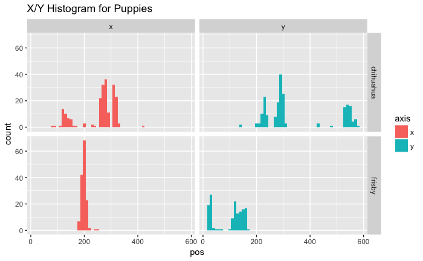

```r
za <- read_csv("../Child Data/_twopuppies/za05da12 6m15d GoodCalibVERYSquirmy_TwoPuppiesData.csv") %>%
  mutate(puppy = case_when(
    mark == 1 ~ "chihuahua",
    mark == 2 ~ "frisby"
  )) %>%
  rename(x = xpos, y = ypos) %>%
  gather(axis, pos, x:y)
ggplot(za, aes(x = pos, fill = axis)) + geom_histogram(binwidth = 10) + ggtitle("X/Y Histogram for Puppies") + facet_grid(puppy ~ axis)
```

```r
za_stats <- za %>%
  group_by(puppy, axis) %>%
  summarise(mean = mean(pos, na.rm=TRUE),
         median = median(pos, na.rm=TRUE)) %>%
  ungroup() %>%
  mutate(offset = median - globalmedian) %>%
  print()
```

| puppy | axis | mean | median | offset |
| --- | --- | --- | --- | --- |
| chihuahua | x | 255.78846 | 276.5 | 32.5 |
| chihuahua | y | 349.89904 | 292.5 | 12.5 |
| frisby | x | 199.41667 | 200.0 | -13.0 |
| frisby | y | 98.51389 | 120.0 | -29.0 |

ZA’s offsets are approximately:

```r
za_stats %>% group_by(axis) %>% summarise(offset = mean(offset))
```

| axis | offset |
| --- | --- |
| x | 9.75 |
| y | -8.25 |

# New Kids

## Stella 5.81 y CODA GOOD

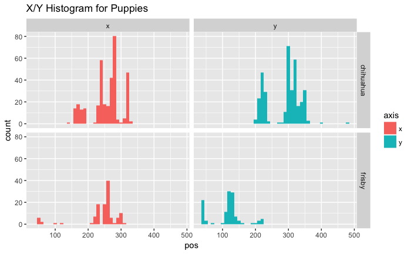

```r
stella <- read_csv("../Child Data/_twopuppies/Stella 5.81 y CODA GOOD_Rec 02_TwoPuppiesData.csv") %>%
  mutate(puppy = case_when(
    mark == 1 ~ "chihuahua",
    mark == 2 ~ "frisby"
  )) %>%
  rename(x = xpos, y = ypos) %>%
  gather(axis, pos, x:y)
ggplot(stella, aes(x = pos, fill = axis)) + geom_histogram(binwidth = 10) + ggtitle("X/Y Histogram for Puppies") + facet_grid(puppy ~ axis)
```

```r
stella_stats <- stella %>%
  group_by(puppy, axis) %>%
  summarise(mean = mean(pos, na.rm=TRUE),
         median = median(pos, na.rm=TRUE)) %>%
  ungroup() %>%
  mutate(offset = median - globalmedian) %>%
  print()
```

| puppy | axis | mean | median | offset |
| --- | --- | --- | --- | --- |
| chihuahua | x | 255.1197 | 267 | 23 |
| chihuahua | y | 289.8490 | 304 | 24 |
| frisby | x | 240.9492 | 258 | 45 |
| frisby | y | 114.8305 | 122 | -27 |

Stella’s offsets are approximately:

```r
stella_stats %>% group_by(axis) %>% summarise(offset = mean(offset))
```

| axis | offset |
| --- | --- |
| x | 34.0 |
| y | -1.5 |

## Ethan 10.5 y CODA GOOD

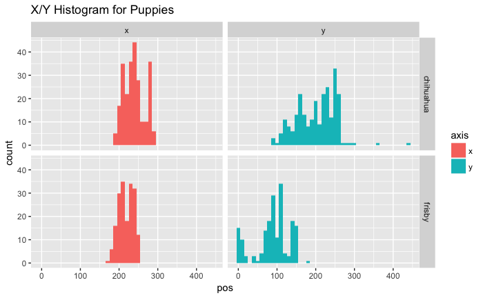

```r
ethan <- read_csv("../Child Data/_twopuppies/Ethan 10.5 y CODA GOOD_Rec 04_TwoPuppiesData.csv") %>%
  mutate(puppy = case_when(
    mark == 1 ~ "chihuahua",
    mark == 2 ~ "frisby"
  )) %>%
  rename(x = xpos, y = ypos) %>%
  gather(axis, pos, x:y)
ggplot(ethan, aes(x = pos, fill = axis)) + geom_histogram(binwidth = 10) + ggtitle("X/Y Histogram for Puppies") + facet_grid(puppy ~ axis)
```

```r
ethan_stats <- ethan %>%
  group_by(puppy, axis) %>%
  summarise(mean = mean(pos, na.rm=TRUE),
         median = median(pos, na.rm=TRUE)) %>%
  ungroup() %>%
  mutate(offset = median - globalmedian) %>%
  print()
```

| puppy | axis | mean | median | offset |
| --- | --- | --- | --- | --- |
| chihuahua | x | 239.73896 | 240 | -4 |
| chihuahua | y | 202.87149 | 213 | -67 |
| frisby | x | 218.87500 | 220 | 7 |
| frisby | y | 89.64674 | 94 | -55 |

Ethan’s offsets are approximately:

```r
ethan_stats %>% group_by(axis) %>% summarise(offset = mean(offset))
```

| axis | offset |
| --- | --- |
| x | 1.5 |
| y | -61.0 |

## Marcus 8.15 y CODA GOOD

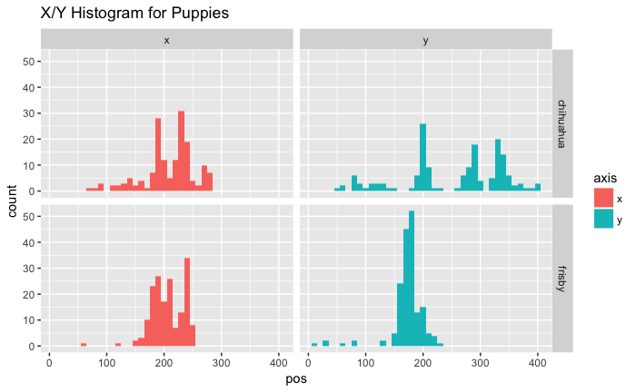

```r
marcus <- read_csv("../Child Data/_twopuppies/Marcus 8.15 y CODA GOOD_Rec 05_TwoPuppiesData.csv") %>%
  mutate(puppy = case_when(
    mark == 1 ~ "chihuahua",
    mark == 2 ~ "frisby"
  )) %>%
  rename(x = xpos, y = ypos) %>%
  gather(axis, pos, x:y)
ggplot(marcus, aes(x = pos, fill = axis)) + geom_histogram(binwidth = 10) + ggtitle("X/Y Histogram for Puppies") + facet_grid(puppy ~ axis)
```

```r
marcus_stats <- marcus %>%
  group_by(puppy, axis) %>%
  summarise(mean = mean(pos, na.rm=TRUE),
         median = median(pos, na.rm=TRUE)) %>%
  ungroup() %>%
  mutate(offset = median - globalmedian) %>%
  print()
```

| puppy | axis | mean | median | offset |
| --- | --- | --- | --- | --- |
| chihuahua | x | 208.9938 | 220 | -24 |
| chihuahua | y | 254.7950 | 283 | 3 |
| frisby | x | 206.6337 | 207 | -6 |
| frisby | y | 173.6744 | 176 | 27 |

Marcus’s offsets are approximately:

```r
marcus_stats %>% group_by(axis) %>% summarise(offset = mean(offset))
```

| axis | offset |
| --- | --- |
| x | -15 |
| y | 15 |

## GiaLessa 2y2m CODA

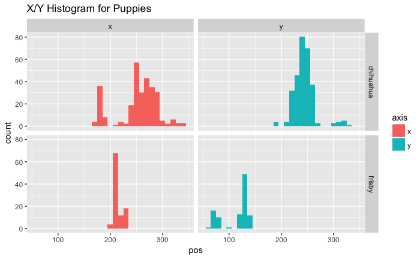

```r
gialessa <- read_csv("../Child Data/_twopuppies/GiaLessa 2y2m CODA_Rec 03_TwoPuppiesData.csv") %>%
  mutate(puppy = case_when(
    mark == 1 ~ "chihuahua",
    mark == 2 ~ "frisby"
  )) %>%
  rename(x = xpos, y = ypos) %>%
  gather(axis, pos, x:y)
ggplot(gialessa, aes(x = pos, fill = axis)) + geom_histogram(binwidth = 10) + ggtitle("X/Y Histogram for Puppies") + facet_grid(puppy ~ axis)
```

```r
gialessa_stats <- gialessa %>%
  group_by(puppy, axis) %>%
  summarise(mean = mean(pos, na.rm=TRUE),
         median = median(pos, na.rm=TRUE)) %>%
  ungroup() %>%
  mutate(offset = median - globalmedian) %>%
  print()
```

| puppy | axis | mean | median | offset |
| --- | --- | --- | --- | --- |
| chihuahua | x | 254.0623 | 262 | 18 |
| chihuahua | y | 244.4844 | 243 | -37 |
| frisby | x | 214.7941 | 212 | -1 |
| frisby | y | 115.4706 | 128 | -21 |

gialessa’s offsets are approximately:

```r
gialessa_stats %>% group_by(axis) %>% summarise(offset = mean(offset))
```

| axis | offset |
| --- | --- |
| x | 8.5 |
| y | -29.0 |

## Olivia CODA 2.5 y

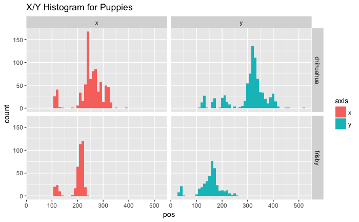

```r
olivian <- read_csv("../Child Data/_twopuppies/Olivia CODA 2.5 y_Rec 06_TwoPuppiesData.csv") %>%
  mutate(puppy = case_when(
    mark == 1 ~ "chihuahua",
    mark == 2 ~ "frisby"
  )) %>%
  rename(x = xpos, y = ypos) %>%
  gather(axis, pos, x:y)
ggplot(olivian, aes(x = pos, fill = axis)) + geom_histogram(binwidth = 10) + ggtitle("X/Y Histogram for Puppies") + facet_grid(puppy ~ axis)
```

```r
olivian_stats <- olivian %>%
  group_by(puppy, axis) %>%
  summarise(mean = mean(pos, na.rm=TRUE),
         median = median(pos, na.rm=TRUE)) %>%
  ungroup() %>%
  mutate(offset = median - globalmedian) %>%
  print()
```

| puppy | axis | mean | median | offset |
| --- | --- | --- | --- | --- |
| chihuahua | x | 250.2119 | 253 | 9 |
| chihuahua | y | 305.6393 | 323 | 43 |
| frisby | x | 199.2967 | 211 | -2 |
| frisby | y | 152.6087 | 160 | 11 |

Olivia’s offsets are approximately:

```r
olivian_stats %>% group_by(axis) %>% summarise(offset = mean(offset))
```

| axis | offset |
| --- | --- |
| x | 3.5 |
| y | 27.0 |

## Zadre

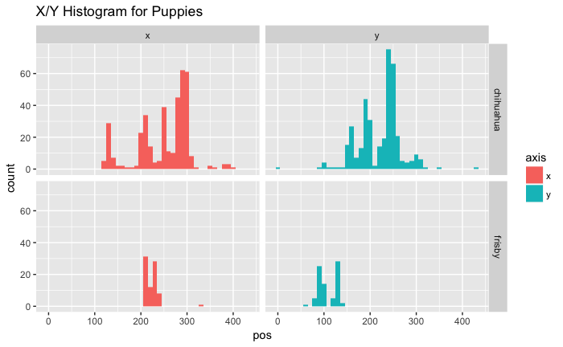

```r
zadre <- read_csv("../Child Data/_twopuppies/za02pa_1y11m_Rec 07_TwoPuppiesData.csv") %>%
  mutate(puppy = case_when(
    mark == 1 ~ "chihuahua",
    mark == 2 ~ "frisby"
  )) %>%
  rename(x = xpos, y = ypos) %>%
  gather(axis, pos, x:y)
ggplot(zadre, aes(x = pos, fill = axis)) + geom_histogram(binwidth = 10) + ggtitle("X/Y Histogram for Puppies") + facet_grid(puppy ~ axis)
```

```r
zadre_stats <- zadre %>%
  group_by(puppy, axis) %>%
  summarise(mean = mean(pos, na.rm=TRUE),
         median = median(pos, na.rm=TRUE)) %>%
  ungroup() %>%
  mutate(offset = median - globalmedian) %>%
  print()
```

| puppy | axis | mean | median | offset |
| --- | --- | --- | --- | --- |
| chihuahua | x | 251.7261 | 275.0 | 31.0 |
| chihuahua | y | 221.1277 | 237.5 | -42.5 |
| frisby | x | 223.3125 | 222.5 | 9.5 |
| frisby | y | 108.1875 | 98.5 | -50.5 |

Zadre’s offsets are approximately:

```r
zadre_stats %>% group_by(axis) %>% summarise(offset = mean(offset))
```

| axis | offset |
| --- | --- |
| x | 20.25 |
| y | -46.50 |

## Janie CODA 16 m

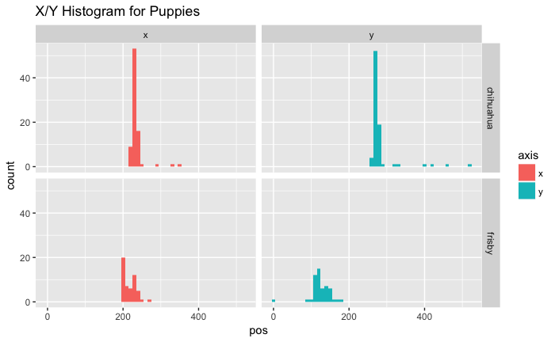

```r
janie <- read_csv("../Child Data/_twopuppies/Janie CODA 16 m_Rec 08_TwoPuppiesData.csv") %>%
  mutate(puppy = case_when(
    mark == 1 ~ "chihuahua",
    mark == 2 ~ "frisby"
  )) %>%
  rename(x = xpos, y = ypos) %>%
  gather(axis, pos, x:y)
ggplot(janie, aes(x = pos, fill = axis)) + geom_histogram(binwidth = 10) + ggtitle("X/Y Histogram for Puppies") + facet_grid(puppy ~ axis)
```

```r
janie_stats <- janie %>%
  group_by(puppy, axis) %>%
  summarise(mean = mean(pos, na.rm=TRUE),
         median = median(pos, na.rm=TRUE)) %>%
  ungroup() %>%
  mutate(offset = median - globalmedian) %>%
  print()
```

| puppy | axis | mean | median | offset |
| --- | --- | --- | --- | --- |
| chihuahua | x | 234.9634 | 232.0 | -12.0 |
| chihuahua | y | 283.0854 | 274.0 | -6.0 |
| frisby | x | 217.4423 | 211.5 | -1.5 |
| frisby | y | 125.3846 | 120.0 | -29.0 |

Janie’s offsets are approximately:

```r
janie_stats %>% group_by(axis) %>% summarise(offset = mean(offset))
```

| axis | offset |
| --- | --- |
| x | -6.75 |
| y | -17.50 |

## luca_27m

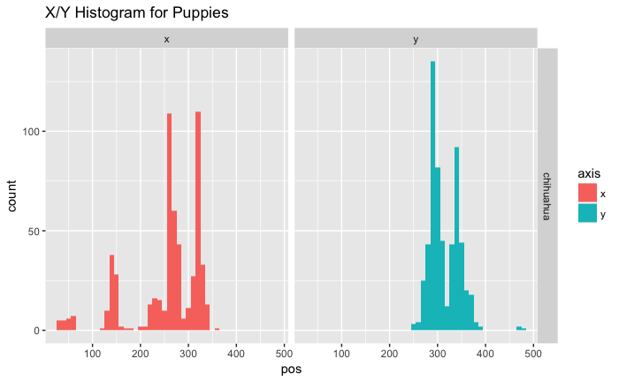

```r
luca <- read_csv("../Child Data/_twopuppies/luca_27m_Rec 05_TwoPuppiesData.csv") %>%
  mutate(puppy = case_when(
    mark == 1 ~ "chihuahua",
    mark == 2 ~ "frisby"
  )) %>%
  rename(x = xpos, y = ypos) %>%
  gather(axis, pos, x:y)
ggplot(luca, aes(x = pos, fill = axis)) + geom_histogram(binwidth = 10) + ggtitle("X/Y Histogram for Puppies") + facet_grid(puppy ~ axis)
```

```r
luca_stats <- luca %>%
  group_by(puppy, axis) %>%
  summarise(mean = mean(pos, na.rm=TRUE),
         median = median(pos, na.rm=TRUE)) %>%
  ungroup() %>%
  mutate(offset = median - globalmedian[1:2]) %>%
  print()
```

| puppy | axis | mean | median | offset |
| --- | --- | --- | --- | --- |
| chihuahua | x | 256.1409 | 266 | 22 |
| chihuahua | y | 314.4452 | 304 | 24 |

Luca’s offsets are approximately:

```r
luca_stats %>% group_by(axis) %>% summarise(offset = mean(offset))
```

| axis | offset |
| --- | --- |
| x | 22 |
| y | 24 |

## Parker 6 m SIGNING

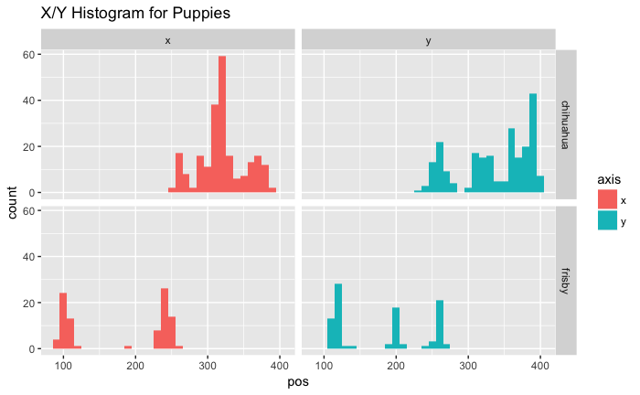

```r
parker <- read_csv("../Child Data/_twopuppies/Parker 6 m SIGNING_Rec 09_TwoPuppiesData.csv") %>%
  mutate(puppy = case_when(
    mark == 1 ~ "chihuahua",
    mark == 2 ~ "frisby"
  )) %>%
  rename(x = xpos, y = ypos) %>%
  gather(axis, pos, x:y)
ggplot(parker, aes(x = pos, fill = axis)) + geom_histogram(binwidth = 10) + ggtitle("X/Y Histogram for Puppies") + facet_grid(puppy ~ axis)
```

```r
parker_stats <- parker %>%
  group_by(puppy, axis) %>%
  summarise(mean = mean(pos, na.rm=TRUE),
         median = median(pos, na.rm=TRUE)) %>%
  ungroup() %>%
  mutate(offset = median - globalmedian) %>%
  print()
```

| puppy | axis | mean | median | offset |
| --- | --- | --- | --- | --- |
| chihuahua | x | 320.4178 | 319.0 | 75.0 |
| chihuahua | y | 337.0089 | 356.0 | 76.0 |
| frisby | x | 177.8804 | 234.0 | 21.0 |
| frisby | y | 179.4130 | 197.5 | 48.5 |

Parker’s offsets are approximately:

```r
parker_stats %>% group_by(axis) %>% summarise(offset = mean(offset))
```

| axis | offset |
| --- | --- |
| x | 48.00 |
| y | 62.25 |

## Penn 6 months SIGN EXPOSED

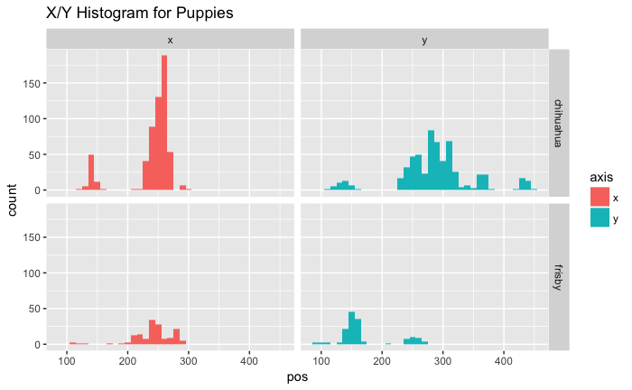

```r
penn <- read_csv("../Child Data/_twopuppies/Penn 6 months SIGN EXPOSED_Rec 06_TwoPuppiesData.csv") %>%
  mutate(puppy = case_when(
    mark == 1 ~ "chihuahua",
    mark == 2 ~ "frisby"
  )) %>%
  rename(x = xpos, y = ypos) %>%
  gather(axis, pos, x:y)
ggplot(penn, aes(x = pos, fill = axis)) + geom_histogram(binwidth = 10) + ggtitle("X/Y Histogram for Puppies") + facet_grid(puppy ~ axis)
```

```r
penn_stats <- penn %>%
  group_by(puppy, axis) %>%
  summarise(mean = mean(pos, na.rm=TRUE),
         median = median(pos, na.rm=TRUE)) %>%
  ungroup() %>%
  mutate(offset = median - globalmedian) %>%
  print()
```

| puppy | axis | mean | median | offset |
| --- | --- | --- | --- | --- |
| chihuahua | x | 240.2715 | 253 | 9 |
| chihuahua | y | 287.8007 | 286 | 6 |
| frisby | x | 242.9054 | 244 | 31 |
| frisby | y | 171.2297 | 155 | 6 |

Penn’s offsets are approximately:

```r
penn_stats %>% group_by(axis) %>% summarise(offset = mean(offset))
```

| axis | offset |
| --- | --- |
| x | 20 |
| y | 6 |

## Victoria 8 months SIGN EXPOSED

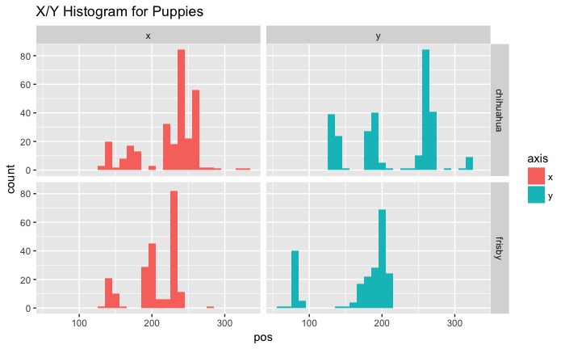

```r
victoria <- read_csv("../Child Data/_twopuppies/Victoria07_18_17_Rec 10_TwoPuppiesData.csv") %>%
  mutate(puppy = case_when(
    mark == 1 ~ "chihuahua",
    mark == 2 ~ "frisby"
  )) %>%
  rename(x = xpos, y = ypos) %>%
  gather(axis, pos, x:y)
ggplot(victoria, aes(x = pos, fill = axis)) + geom_histogram(binwidth = 10) + ggtitle("X/Y Histogram for Puppies") + facet_grid(puppy ~ axis)
```

```r
victoria_stats <- victoria %>%
  group_by(puppy, axis) %>%
  summarise(mean = mean(pos, na.rm=TRUE),
         median = median(pos, na.rm=TRUE)) %>%
  ungroup() %>%
  mutate(offset = median - globalmedian) %>%
  print()
```

| puppy | axis | mean | median | offset |
| --- | --- | --- | --- | --- |
| chihuahua | x | 224.8596 | 238 | -6 |
| chihuahua | y | 216.4667 | 253 | -27 |
| frisby | x | 205.3333 | 205 | -8 |
| frisby | y | 168.2488 | 191 | 42 |

Victoria’s offsets are approximately:

```r
victoria_stats %>% group_by(axis) %>% summarise(offset = mean(offset))
```

| axis | offset |
| --- | --- |
| x | -7.0 |
| y | 7.5 |

## Ke11es12 7.5 Mo SE

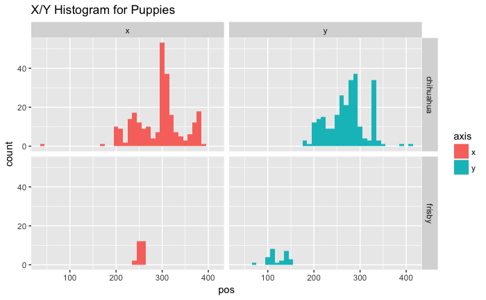

```r
kelles <- read_csv("../Child Data/_twopuppies/ke11es12_13_7m GOOD_TwoPuppiesData.csv") %>%
  mutate(puppy = case_when(
    mark == 1 ~ "chihuahua",
    mark == 2 ~ "frisby"
  )) %>%
  rename(x = xpos, y = ypos) %>%
  gather(axis, pos, x:y)
ggplot(kelles, aes(x = pos, fill = axis)) + geom_histogram(binwidth = 10) + ggtitle("X/Y Histogram for Puppies") + facet_grid(puppy ~ axis)
```

```r
kelles_stats <- kelles %>%
  group_by(puppy, axis) %>%
  summarise(mean = mean(pos, na.rm=TRUE),
         median = median(pos, na.rm=TRUE)) %>%
  ungroup() %>%
  mutate(offset = median - globalmedian) %>%
  print()
```

| puppy | axis | mean | median | offset |
| --- | --- | --- | --- | --- |
| chihuahua | x | 293.1969 | 302.0 | 58.0 |
| chihuahua | y | 271.8386 | 276.5 | -3.5 |
| frisby | x | 254.4231 | 255.0 | 42.0 |
| frisby | y | 123.0769 | 118.5 | -30.5 |

Ke11es12’s offsets are approximately:

```r
kelles_stats %>% group_by(axis) %>% summarise(offset = mean(offset))
```

| axis | offset |
| --- | --- |
| x | 50 |
| y | -17 |

## Trinity SE

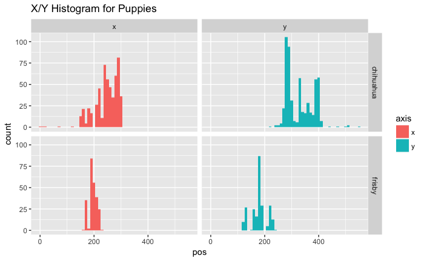

```r
#trinity <- read_csv("../Child Data/_twopuppies/Trinity 8m_Rec 07_TwoPuppiesData.csv") %>%
trinity <- read_csv("~/Downloads/Trinity 8m_Rec 07_TwoPuppiesData.csv") %>%
  mutate(puppy = case_when(
    mark == 1 ~ "chihuahua",
    mark == 2 ~ "frisby"
  )) %>%
  rename(x = xpos, y = ypos) %>%
  gather(axis, pos, x:y)
ggplot(trinity, aes(x = pos, fill = axis)) + geom_histogram(binwidth = 10) + ggtitle("X/Y Histogram for Puppies") + facet_grid(puppy ~ axis)
```

```r
trinity_stats <- trinity %>%
  group_by(puppy, axis) %>%
  summarise(mean = mean(pos, na.rm=TRUE),
         median = median(pos, na.rm=TRUE)) %>%
  ungroup() %>%
  mutate(offset = median - globalmedian) %>%
  print()
```

| puppy | axis | mean | median | offset |
| --- | --- | --- | --- | --- |
| chihuahua | x | 246.0835 | 253 | 9 |
| chihuahua | y | 329.6515 | 327 | 47 |
| frisby | x | 195.9588 | 195 | -18 |
| frisby | y | 179.0658 | 182 | 33 |

Trinity’s offsets are approximately:

```r
trinity_stats %>% group_by(axis) %>% summarise(offset = mean(offset))
```

| axis | offset |
| --- | --- |
| x | -4.5 |
| y | 40.0 |